# Assignment 2: Webots Tutorials

**Due September 5, 2022 by 5pm**

In ES302, we will be modeling and testing robots in simulation before running experiments. This will allow us to predict how our robots will behave before we subject them or their environments to undue risk with an experiment. As we did in ES103, we will use a disciplined process that is rooted in the model->predict->validate paradigm.

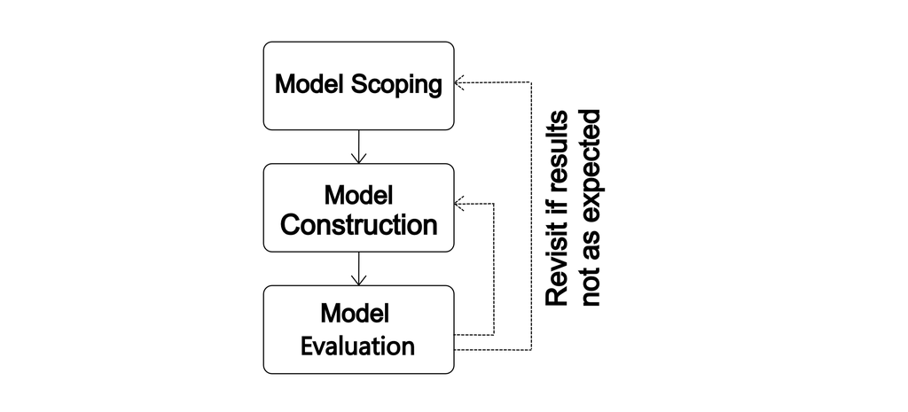

As we did in ES103, we will sometimes be employing physics-based differential equation models, lookup table models, or other methods to build simulations of robot behavior "from scratch," but as the complexity of a robot, a group of robots, or a robot-environment system increases, the methods we learned in ES103 will quickly meet their limitations.

To deal with this, we will be using a commercial robot simulation package called WeBots. This software is very powerful, but the development team has created a series of tutorials that make learning how it works quick and easy.

## Prerequisite Skill: Google Drive

You have been given access to a Google Drive folder called ES302_YourLastName. Search for "ES302" in drive.google.com under "shared with me." Make sure to add a shortcut to this folder to your drive so that it shows up on your computer when you install and use [Drive for Desktop](https://www.google.com/drive/download/). Installing Drive for Desktop with your lafayette credentials will allow you to work on your assignments for this class seamlessly across devices, and allow your instructor access to your work in order to provide feedback.

Working in Drive for Desktop will also allow you to use [git](https://git-scm.com/download/win) to version-control your work or to pull down the latest version of the libraries and other software I have written for this course.

## Deliverables

### Deliverable 1

Complete tutorials 1, 2, 4, and 6 in Webots *using the Python Language* for all controller programming. Please see the python resources if you need a quick introduction to Python. **Place your final code for these tutorials along with a video of each of your simulations (use the "record video" feature in WeBots) into your ES302 Google Drive folder under the subfolder A02/**

### Deliverable 2

[Install Git](https://git-scm.com/download/win) for your operating system. If you have Mac or Linux, it may already be installed. If you are using a classroom computer, it is already installed.

```
$ git clone https://github.com/Alexanderallenbrown/ES302_Webots.git
    $ cd ES302_Webots
    $ git submodule update --remote
```

Then, open the world romi_demo.wbt, and modify the romi_demo controller to double the frequency at which the wheels change direction, and halve the frequency at which the servo motors move. Note that I have written a library for you that specifically interacts with the Romi in Webots. [This library](https://github.com/Alexanderallenbrown/ES302_Romi) mimics the *actual* Romi more closely than the "raw" Webots system can. See the library's homepage on GitHub for help on its use. You can also see the Romi Resource page for more information on the Romi robots we have in ES302.